# Tutorial_2_Model calibration for humans

Wei-Chun Chou

June, 2020

# Introduction

The document gives you a simple tutorial to run the model calibration for the human gestational and lactational PBPK model.

# Prerequisites

Before running your model, you should set up your working directory, compile the PBPK model, install all required packages and input needed datasets. The model file and datasets can be found in the additional files.

## Setting up your working directory

Before running, you should change your working directory to the **ModFit** folder. You can used two way to change your working directory as follow:

1. Use RStudio: use the menu to change your working directory under **Session > Set Working Directory > Choose Directory**.
2. Use R function: use the R function `setwd()` to change the path to your working directory.

## Loading required R packages

The list of R packages should be installed prior to the simulation. If you have not installed these packages (listed below), please install these packages to your Rstudio using the R function `require (" ")` and then use `library` open it.

```r
library(mrgsolve)    ## R-package for Loading mrgsolve code
library(magrittr)    ## R-package for the pipe, %>% ,
library(dplyr)       ## R-package for transform and summarize tabular data with rows and columns; %>%
library(tidyverse)   ## R-package for transform and summarize tabular data with rows and columns; %>%
library(ggplot2)     ## R-package for GGplot
library(FME)         ## R-package for model fitting
library(minpack.lm)  ## R-package for model fitting
```

## Read mrgsolve-based PBPK Model R file

```r
source (file = "HMod.R")  ## PBPK model for humans
```

## Build mrgsolve-based PBPK Model

Read the code and build these mrgsolve-based PBPK models. You should make sure all models were built correctly.

```r
PreGmod_H <- mcode ("PreGHumanPBPK.code", PreGHumanPBPK.code) # bulid the pre-pregnant model
```

```
## Building PreGHumanPBPK_code ... done.
```

```r
Gmod_H    <- mcode ("GHumanPBPK.code", GHumanPBPK.code) # bulid the gestational model
```

```
## Building GHumanPBPK_code ... done.
```

```r
Lmod_H    <- mcode ("LHumanPBPK.code", LHumanPBPK.code) # bulid the lactational model
```

```
## Building LHumanPBPK_code ... done.
```

## Loading datasets for model calibration

In this step, you need to input the .csv file to the Rstudio. The function `read.csv` can be used to read the csv file into R

```r
Data_0    <- read.csv(file = "Data_H.csv")
Data_Cal  <- Data_0 %>% filter(Cal == 1)
```

# Model calibration for the gestational PBPK model

## Read these datasets and later used in model calibration

These datasets were collected from human biomonitoring data.  
Abbrevation: MP: Maternal plasma, CB: cord blood, Pla: placenta; Fli: Fetal liver

- A1. (Inoue et al., 2004) : Japan population; Matrix: MP, CB
- A2. (Fei et al., 2007) : Danish population; Matrix: MP, CB
- A3. (Kato et al., 2014) : U.S. population; Matrix: MP, CB
- A4. (Pan et al., 2017) : Chinese population; Matrix: MP, CB
- A5. (Mamsen et al., 2019) : Sweden population; Matrix: MP, Pla, Fli
- A6. (Midasch et al., 2007) : German population; Matrix: MP, CB

```r
## Read the data and later used in model calibration
OBS.A1_MP     <- Data_Cal %>% filter(Study == 1 & Matrix == "MP") %>% select(Time = "Time",  CPlas   = "Conc")
OBS.A1_CB     <- Data_Cal %>% filter(Study == 1 & Matrix == "CB") %>% select(Time = "Time",  CFPlas  = "Conc")
OBS.A2_MP     <- Data_Cal %>% filter(Study == 2 & Matrix == "MP") %>% select(Time = "Time",  CPlas   = "Conc")
OBS.A2_CB     <- Data_Cal %>% filter(Study == 2 & Matrix == "CB") %>% select(Time = "Time",  CFPlas  = "Conc")
OBS.A3_MP     <- Data_Cal %>% filter(Study == 3 & Matrix == "MP") %>% select(Time = "Time",  CPlas   = "Conc")
OBS.A3_CB     <- Data_Cal %>% filter(Study == 3 & Matrix == "CB") %>% select(Time = "Time",  CFPlas  = "Conc")
OBS.A4_MP     <- Data_0 %>% filter(Study == 4 & Matrix == "MP") %>% select(Time = "Time",  CPlas   = "Conc")
OBS.A4_CB     <- Data_0 %>% filter(Study == 4 & Matrix == "CB") %>% select(Time = "Time",  CFPlas  = "Conc")
OBS.A5_MP     <- Data_0 %>% filter(Study == 5 & Matrix == "MP") %>% select(Time = "Time",  CPlas   = "Conc")
OBS.A5_Pla    <- Data_0 %>% filter(Study == 5 & Matrix == "Pla") %>% select(Time = "Time", CPla    = "Conc")
OBS.A5_Fli    <- Data_0 %>% filter(Study == 5 & Matrix == "Fli") %>% select(Time = "Time", CFL     = "Conc")
OBS.A6_MP     <- Data_0 %>% filter(Study == 6 & Matrix == "MP") %>% select(Time = "Time",  CPlas   = "Conc")
OBS.A6_CB     <- Data_0 %>% filter(Study == 6 & Matrix == "CB") %>% select(Time = "Time",  CFPlas  = "Conc")
```

## Define the prediction function for the gestational model calibration

Here, we define two prediction functions:

1. **pred.preG**: Simulate the time-varying profiles of PFOS for non-pregnant period (0-30 years).
2. **pred.G**: Simulate the time-varying profiles of PFOS during gestation (GA0 - GA40).

The concentrations of PFOS for non-pregnant women (daily exposed to PFOS from birth to 30 years old) are used as intial concentrations of the gestaitonal model

```r
## Exposure scenario:  Dosing druing pregnnacy from pre-pregnant to gestational period
pred.preG <- function (DOSE) {

    ## Define the exposure scenario for age specific data
    ex <- tibble(ID   = rep(1, 365*30 + 1), # individual ID
                 time = seq(from = 0, to = 24*365*30, by = 24)) %>% # time from 0 to 30 years
        mutate (DAY   = time/24) %>%  # DAY
        mutate (YEAR  = DAY/365) %>%  # AGE
        mutate (BW    = if_else(YEAR <= 18, # if age small than or equal to 18 years old use the equation; otherwise bodyweight equal to about 54 kg (Haddad et al. 2001)
                                true  = (-2.561*YEAR^4 + 85.576*YEAR^3 - 855.95*YEAR^2 + 5360.6*YEAR + 4428.5)/1000,
                                ifelse(YEAR >= 30, 67, 54))) # (67 is from Loccisano et al. 2013C)

    tsamp <- tgrid (start = 0, end = 365*30, delta = 0.1) # simulation time from 0 to 30 years old, and the time interval is 0.1 h

    ## Exposure scenario: A dynamic exposure model for PFOS daily intakes
    ## a constant exposure (per kg of bodyweight) Initially, intended to separate dose levels before and after 2000, but later on used one constant exposure level
    PDOSEoral_1 = DOSE
    ex_1 <- mutate (ex,
                    amt = case_when (YEAR < 20 ~ PDOSEoral_1*BW,
                                         YEAR >= 20 ~ PDOSEoral_1*BW),
                    cmt  = "AST",
                    ii = 24,
                    evid = 1, ## extravascular administration ID.
                    time = DAY)


    out <- PreGmod_H %>%
        update(atol = 1E-3, maxsteps = 500000) %>%
        mrgsim_d(data = ex_1, tgrid = tsamp)%>%
        filter (time > 0)

    return (out)
}

## Simulate the initial concentration of the gestational model based on different exposure scenarios
## The assumed epxosure doses were estimated from previous studies
## Init_A1: Japan population;   Dose: 1.2 ng/kg/day estiamted from Table 5 in Loccisano et al. (2013);
## Init_A2: Danish population;  Dose: 3.7 ng/kg/day estiamted from Table 5 in Loccisano et al. (2013);
## Init_A3: U.S. population     Dose: 0.1 - 2 ng/kg/day estimated from Loccisano et al. (2014)
## Init_A4: Chinese population  Dose: 1.1 ng/kg/day estimaed from Zhang et al. (2010)
## Init_A5: Sweden population   Dose: 0.860 - 1.44 ng/kg/day estimated from Robin Vestergren et al. (2012)
## Init_A6: Germany population  Dose: 1.35 ng/kg/day estimated from Table 5 in Loccisano et al. (2013);

DOSE_A1 <- 1.2e-6
DOSE_A2 <- 3.7e-6
DOSE_A3 <- 1.5e-6
DOSE_A4 <- 1.1e-6
DOSE_A5 <- 0.86e-6
DOSE_A6 <- 1.35e-6

Init_A1 <- pred.preG (DOSE = DOSE_A1) %>% filter (row_number()== n()) %>% select(-c("Plasma", "Liver", "Kidney"))
Init_A2 <- pred.preG (DOSE = DOSE_A2) %>% filter (row_number()== n()) %>% select(-c("Plasma", "Liver", "Kidney"))
Init_A3 <- pred.preG (DOSE = DOSE_A3) %>% filter (row_number()== n()) %>% select(-c("Plasma", "Liver", "Kidney"))
Init_A4 <- pred.preG (DOSE = DOSE_A4) %>% filter (row_number()== n()) %>% select(-c("Plasma", "Liver", "Kidney"))
Init_A5 <- pred.preG (DOSE = DOSE_A5) %>% filter (row_number()== n()) %>% select(-c("Plasma", "Liver", "Kidney"))
Init_A6 <- pred.preG (DOSE = DOSE_A6) %>% filter (row_number()== n()) %>% select(-c("Plasma", "Liver", "Kidney"))

## Exposure sceinario
pred.G <- function(Gpars, DOSE, Init) {

    ## Get out of log domain
    Gpars <- lapply(Gpars, exp)           ## Return a list of exp (parameters for gestational model) from log scale

    ## Exposure scenario for gestational exposure
    GBW          = 60                     ## Body weight
    tinterval    = 24                     ## Time interval;
    GTDOSE       = 7*40                   ## Total dosing/Dose times;
    GDOSE        = DOSE                   ## Input oral dose
    GDOSEoral    = GDOSE*GBW              ## Amount of oral dose

    # To create a data set of 1 subject receiving GDOSE every 24 hours
    Gex.oral <- ev (ID   = 1,             ## One individual
                    amt  = GDOSEoral,     ## Amount of dose
                    ii   = tinterval,     ## Time interval
                    addl = GTDOSE - 1,    ## Addtional doseing
                    cmt  = "AST",         ## The dosing comaprtment: AST Stomach
                    tinf = 0.01,          ## Infusion time;
                    replicate = FALSE)    ## No replicate

    Gtsamp  = tgrid(0, tinterval*(GTDOSE - 1) + 24*1, 24) ## Simulation time

    ## Simulation of exposure scenario
    Gout <-
        Gmod_H %>% ## Gestational PBPK model
        init(APlas_free = Init$APlas_free, APTC = Init$APTC, AFil = Init$AFil, AKb = Init$AKb, ARest = Init$ARest,
             AL = Init$AL, AM = Init$AM, AF = Init$AF, A_baso = Init$A_baso, A_apical = Init$A_apical, Adif = Init$Adif,
             Aefflux = Init$Aefflux) %>%  ## Input the intial concentration
        param (Gpars) %>%                 ## Update the parameter list with Gpars
        update(atol = 1E-3,  maxsteps = 500000) %>%  ## Atol: Absolute tolerance parameter; maxsteps:maximum number of steps
        mrgsim_d (data = Gex.oral, tgrid = Gtsamp)

    ## Extract the "Time", "CPlas", "CL" , "CPlas_P", "CPla" and "Curine" from Gout
    Goutdf = cbind.data.frame(Time     = Gout$time,
                              CPlas    = Gout$Plasma*1000,
                              CL       = Gout$Liver*1000,
                              CFPlas   = Gout$CordB*1000,
                              CPla     = Gout$Placenta*1000,
                              CFL      = Gout$Fliver*1000)

    return (Goutdf) # Return Goutdf
}
```

## Create a cost function for gestational model calibration

Define a cost function `Gcost` to estimate the model residual.  
The `modCost` function (from FME package) gives a solution of a model and observed data, estimates the residuals, and the variable and model costs (sum of squared residuals).  
Note:

- `model`: model output; input the simulation value.
- `obs`: input the observed data.
- `cost`: if not NULL, the output of a previous call to modCost; in this case, the new output will combine both.

```r
## Create a cost fuction and later used in model optimization
## Estimate the model residual with experimental data by modCost function (from FME package)
Gcost<-function (pars){
    outdf.A1 <- pred.G (Gpars = pars,  DOSE = DOSE_A1, Init = Init_A1)
    outdf.A2 <- pred.G (Gpars = pars,  DOSE = DOSE_A2, Init = Init_A2)
    outdf.A3 <- pred.G (Gpars = pars,  DOSE = DOSE_A3, Init = Init_A3)
    outdf.A4 <- pred.G (Gpars = pars,  DOSE = DOSE_A4, Init = Init_A4)
    outdf.A5 <- pred.G (Gpars = pars,  DOSE = DOSE_A5, Init = Init_A5)
    outdf.A6 <- pred.G (Gpars = pars,  DOSE = DOSE_A6, Init = Init_A6)

    cost<- modCost  (model = outdf.A1, obs = OBS.A1_MP, x ="Time")
    cost<- modCost  (model = outdf.A1, obs = OBS.A1_CB, x ="Time", cost = cost)
    cost<- modCost  (model = outdf.A2, obs = OBS.A2_MP, x ="Time", cost = cost)
    cost<- modCost  (model = outdf.A2, obs = OBS.A2_CB, x ="Time", cost = cost)
    cost<- modCost  (model = outdf.A3, obs = OBS.A3_MP, x ="Time", cost = cost)
    cost<- modCost  (model = outdf.A3, obs = OBS.A3_CB, x ="Time", cost = cost)
    cost<- modCost  (model = outdf.A4, obs = OBS.A4_MP, x ="Time", cost = cost)
    cost<- modCost  (model = outdf.A4, obs = OBS.A4_CB, x ="Time", cost = cost)
    cost<- modCost  (model = outdf.A4, obs = OBS.A5_MP, x ="Time", cost = cost)
    cost<- modCost  (model = outdf.A4, obs = OBS.A5_Pla, x ="Time", cost = cost)
    cost<- modCost  (model = outdf.A4, obs = OBS.A5_Fli, x ="Time", cost = cost)
    cost<- modCost  (model = outdf.A6, obs = OBS.A6_MP, x ="Time", cost = cost)
    cost<- modCost  (model = outdf.A6, obs = OBS.A6_CB, x ="Time", cost = cost)

    return(cost)
}
```

## List the initial parameters for the later used in sensitivity analysis

All the values of parameters are initial values before optimization from Chou and Lin (2019).

```r
## Local sensitivity analysis
## initial parmaeters
Gtheta.int <- log(c(
    Vmax_baso_invitro              = 479,
    Km_baso                        = 20.1,
    Vmax_apical_invitro            = 51803,
    Km_apical                      = 64.4,
    RAFapi                         = 0.001,
    RAFbaso                        = 1,
    KeffluxC                       = 0.15,
    KbileC                         = 1.3e-4,
    KurineC                        = 0.096,
    Free                           = 0.014,
    PL                             = 2.03,
    PK                             = 1.26,
    PM                             = 0.13,
    PF                             = 0.16,
    PRest                          = 0.20,
    PPla                           = 0.41,
    K0C                            = 1,
    Kabsc                          = 2.12,
    Kdif                           = 0.001,
    KunabsC                        = 7.05e-5,
    Ktrans1C                       = 0.46,
    Ktrans2C                       = 1.01,
    Ktrans3C                       = 0.006,
    Ktrans4C                       = 0.001,
    Free_Fet                       = 0.014,
    PL_Fet                         = 2.03,
    PRest_Fet                      = 0.20
))
```

## Sensitivity function

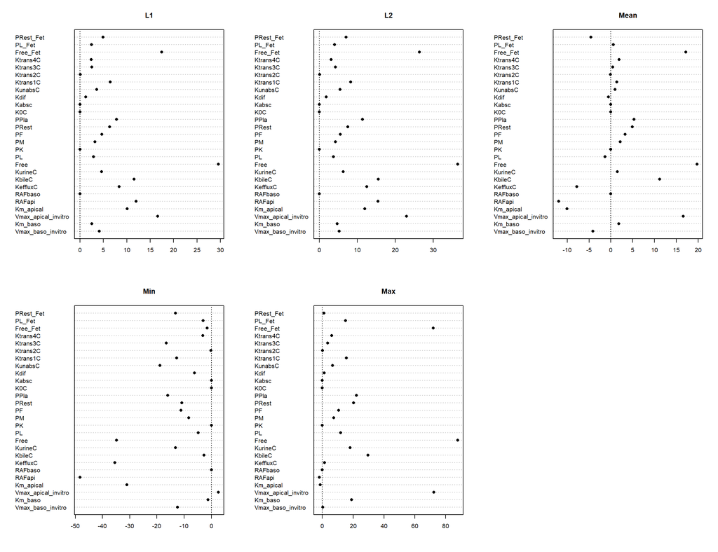

```r
## senFun is the sensitivity analysis function in FME
SnsPlasma <- sensFun(func = Gcost, parms = Gtheta.int, varscale = 1)
Sen       <- summary(SnsPlasma)
plot(summary(SnsPlasma))
```

## Check the sensitive parameters

```r
## Select the parameters that senstive scores higher than 1.2x average socre of all parameters
Gtheta <- Gtheta.int[abs(Sen$Mean) > 1.2*mean(abs(Sen$Mean))]
Gtheta
```

```
## Vmax_apical_invitro           Km_apical              RAFapi            KeffluxC
##           10.855203            4.165114           -6.907755           -1.897120
##              KbileC                Free            Free_Fet
##           -8.947976           -4.268698           -4.268698
```

## Select sensitive parameters and relevant parameters

Since the Levenberg-Marquardt-algorithm is a gradient-based optimization, the identification of a global optimum cannot be guaranteed. We hence also select the parameters that are relevant to calibrated datasets in order to obtain good initial guesses for the optimization.

```r
## Selected parameters
Gtheta <- log(c(
    #Vmax_baso_invitro              = 479,
    #Km_baso                        = 20.1,
    #Vmax_apical_invitro            = 51803,
    Km_apical                      = 64.4,
    #RAFapi                         = 0.001,
    #RAFbaso                        = 1,
    KeffluxC                       = 0.15,
    #KbileC                         = 1.3e-4,
    #KurineC                        = 0.096,
    Free                           = 0.014,
    #PL                             = 2.03,
    #PK                             = 1.26,
    #PM                             = 0.13,
    #PF                             = 0.16,
    #PRest                          = 0.20,
    PPla                           = 0.41,
    #K0C                            = 1,
    #Kabsc                          = 2.12,
    #Kdif                           = 0.001,
    #KunabsC                        = 7.05e-5,
    Ktrans1C                       = 0.46,
    Ktrans2C                       = 1.01,
    #Ktrans3C                       = 0.006,
    #Ktrans4C                       = 0.001,
    Free_Fet                       = 0.014,
    PL_Fet                         = 2.03,
    PRest_Fet                      = 0.20
))
```

## Least squares fit using levenberg-marquart algorithm

The code `modFit` is the function fitting a model to data.  
The component of function:  
- `f`: a function to be minimized; here you need to input the cost function defined above.  
- `p`: initial values for the parameters to be optimized over.  
- `method`: fitting method; here we choose the levenberg-marquart algorithm (“Marq”).  
- `control`: additional control arguments - see details of nls.lm (“Marq”).

```r
GFit <- modFit(f = Gcost, p = Gtheta, method ="Marq",
               control = nls.lm.control(nprint = 1))
```

```
## It.    0, RSS =    915.069, Par. =    4.16511   -1.89712    -4.2687  -0.891598  -0.776529  0.00995033    -4.2687   0.708036   -1.60944
## It.    1, RSS =    166.317, Par. =    4.56233   -2.92845   -4.60862   -1.19248  -0.291429  0.0309557   -4.00958   0.242527   -3.67529
## It.    2, RSS =    136.402, Par. =    5.65698   -4.23712   -5.93496   -1.71918  -0.343681   0.113588   -5.44689  -0.142069   -1.06618
## It.    3, RSS =    133.872, Par. =    5.61357   -4.24931   -5.92397   -2.07457  -0.283051   0.108808   -5.49308  -0.549486   0.635233
## It.    4, RSS =    133.024, Par. =    5.57905   -4.22568   -5.92424   -2.06322  -0.237269   0.108928   -5.52555  -0.547996   0.962081
## It.    5, RSS =    132.143, Par. =    5.55323   -4.21903   -5.92197   -2.04548  -0.258862   0.108998   -5.54437  -0.530097   0.814139
## It.    6, RSS =    131.987, Par. =    5.51987   -4.21689   -5.91785    -2.0415  -0.232357   0.109069   -5.56364   -0.53549   0.937684
## It.    7, RSS =    131.743, Par. =    5.51491   -4.21835   -5.91726    -2.0428  -0.243696   0.109024   -5.56596  -0.541018   0.836236
## It.    8, RSS =    131.742, Par. =    5.51674    -4.2184   -5.91716   -2.03189  -0.235905   0.109038   -5.56632  -0.538214   0.837595
## It.    9, RSS =    131.737, Par. =    5.51349   -4.21871    -5.9173   -2.03246  -0.237837   0.109012   -5.56721   -0.54229    0.85168
## It.   10, RSS =    131.708, Par. =    5.51306   -4.21877   -5.91728   -2.03241  -0.237722    0.10901   -5.56727  -0.543639   0.837325
## It.   11, RSS =    131.701, Par. =    5.51269    -4.2189   -5.91722   -2.03228  -0.237461   0.109013   -5.56742  -0.545216    0.83868
## It.   12, RSS =    131.701, Par. =    5.51269    -4.2189   -5.91722   -2.03228  -0.237461   0.109013   -5.56742  -0.545216    0.83868
```

## Summary of fitting results

The model calibration has completed; Now you can check the fitting results and check the parameter values

```r
summary(GFit)    ## Summary of fitting results
```

```
##
## Parameters:
##           Estimate Std. Error t value Pr(>|t|)
## Km_apical   5.5127     6.1130   0.902    0.382
## KeffluxC   -4.2189     4.6432  -0.909    0.379
## Free       -5.9172     4.7162  -1.255    0.230
## PPla       -2.0323     1.4388  -1.413    0.180
## Ktrans1C   -0.2375     0.6175  -0.385    0.706
## Ktrans2C    0.1090     0.5906   0.185    0.856
## Free_Fet   -5.5674     5.4712  -1.018    0.326
## PL_Fet     -0.5452     1.3174  -0.414    0.685
## PRest_Fet   0.8387     2.6714   0.314    0.758
##
## Residual standard error: 3.067 on 14 degrees of freedom
##
## Parameter correlation:
##           Km_apical KeffluxC     Free      PPla Ktrans1C Ktrans2C Free_Fet
## Km_apical   1.00000  -0.9221 -0.93672  0.026875  0.02142 -0.15801 -0.91230
## KeffluxC   -0.92211   1.0000  0.99881 -0.048895 -0.14316  0.14620  0.97907
## Free       -0.93672   0.9988  1.00000 -0.046759 -0.13935  0.13974  0.98038
## PPla        0.02687  -0.0489 -0.04676  1.000000  0.01550 -0.05851 -0.03927
## Ktrans1C    0.02142  -0.1432 -0.13935  0.015498  1.00000 -0.45117 -0.01318
## Ktrans2C   -0.15801   0.1462  0.13974 -0.058513 -0.45117  1.00000 -0.02558
## Free_Fet   -0.91230   0.9791  0.98038 -0.039269 -0.01318 -0.02558  1.00000
## PL_Fet      0.60052  -0.5490 -0.55297  0.003899 -0.10052 -0.38691 -0.48860
## PRest_Fet  -0.47019   0.2776  0.29012 -0.018113  0.52011  0.01044  0.26921
##              PL_Fet PRest_Fet
## Km_apical  0.600516  -0.47019
## KeffluxC  -0.549027   0.27763
## Free      -0.552967   0.29012
## PPla       0.003899  -0.01811
## Ktrans1C  -0.100521   0.52011
## Ktrans2C  -0.386911   0.01044
## Free_Fet  -0.488597   0.26921
## PL_Fet     1.000000  -0.55008
## PRest_Fet -0.550081   1.00000
```

```r
exp(GFit$par)    ## Convert the log-transformed parameters
```

```
##    Km_apical     KeffluxC         Free         PPla     Ktrans1C     Ktrans2C
## 2.478173e+02 1.471476e-02 2.692669e-03 1.310358e-01 7.886273e-01 1.115177e+00
##     Free_Fet       PL_Fet    PRest_Fet
## 3.820314e-03 5.797168e-01 2.313311e+00
```

## Check your results

```r
Gcost(GFit$par)
```

```
## $model
## [1] 131.7014
##
## $minlogp
## [1] 86.98629
##
## $var
##      name scale N SSR.unweighted SSR.unscaled         SSR
## 1  CFPlas     1 1     9.35205943   9.35205943  9.35205943
## 2   CPlas     1 1     1.83217917   1.83217917  1.83217917
## 3     CFL     1 3     0.95290378   0.95290378  0.95290378
## 4    CPla     1 3     0.18114664   0.18114664  0.18114664
## 5   CPlas     1 3    55.69956126  55.69956126 55.69956126
## 6  CFPlas     1 1     0.85809818   0.85809818  0.85809818
## 7   CPlas     1 3    50.54831022  50.54831022 50.54831022
```

[output cut: 35 more lines]

# Model calibration for the lactational PBPK model

## Read these datasets and later used in model calibration

These datasets collected from human biomonitoring data.  
Abbreviation: MP: Maternal plasma, NP: Neonatal plasma

- B1. (Karrman et al., 2007) : Sweden population; Matrix: MP, Milk
- B2. (Von Ehrenstein et al., 2009): U.S. population; Matrix: MP
- B3. (Fromme et al., 2010) : Germany population; Matrix: MP, NP
- B4. (Lee et al., 2018) : South Korean; Matrix: Milk

```r
## Read the data and later used in model calibration and evluation
OBS.B1_MP   <- Data_Cal %>% filter(Study == 16 & Matrix == "MP")%>% select(Time = "Time", CPlas = "Conc")
OBS.B1_Milk <- Data_Cal %>% filter(Study == 16 & Matrix == "Milk") %>% select(Time = "Time", CMilk = "Conc")
OBS.B2_MP   <- Data_Cal %>% filter(Study == 17 & Matrix == "MP")   %>% select(Time = "Time", CPlas = "Conc")
OBS.B3_MP   <- Data_Cal %>% filter(Study == 18 & Matrix == "MP")   %>% select(Time = "Time", CPlas = "Conc")
OBS.B3_NP   <- Data_Cal %>% filter(Study == 18 & Matrix == "NP")   %>% select(Time = "Time", CPlas_pup = "Conc")
OBS.B4_Milk <- Data_Cal %>% filter(Study == 19 & Matrix == "Milk") %>% select(Time = "Time", CMilk = "Conc")
```

## Define the prediction function for the lactational model calibration

Here, we define two prediction functions:

1. **pred.G2**: Simulate the time-varying profiles of PFOS from pre-pregnant to the end of gestational period.
2. **pred.L**: Simulate the time-varying profiles of PFOS during lactation.

The concentrations of PFOS for pregnant women (daily exposed to PFOS from non-pregnant to gestation period) are used as intial concentrations for the lactational model

```r
## Prediction function from pre-pregnant to the end of gestational exposure
pred.G2 <- function(DOSE) {

    Init <- pred.preG (DOSE) %>% filter (row_number()== n()) %>% select(-c("Plasma", "Liver", "Kidney"))

    ## Get out of log domain
    Gpars <- lapply(GFit$par, exp)        ## Return a list of exp (parametrs for gestational model) from log scale

    ## Exposure scenario for gestational exposure
    GBW          = 67                     ## Body weight during gestation (a representative body weight to calculate the dose)
    tinterval    = 24                     ## Time interval;
    GTDOSE       = 7*40                   ## Total dosing/Dose times;
    GDOSE        = DOSE                   ## Input oral dose
    GDOSEoral    = GDOSE*GBW              ## Amount of oral dose

    # To create a data set of 1 subject receiving DOSE every 24 hours
    Gex.oral <- ev (ID   = 1,             ## One individual
                    time = 0,             ## Dossed strat time
                    amt  = GDOSEoral,     ## Amount of dose
                    ii   = tinterval,     ## Time interval
                    addl = GTDOSE - 1,    ## Addtional dosing
                    cmt  = "AST",         ## The dosing compartment: AST Stomach
                    tinf = 0.01,          ## Infusion time;
                    replicate = FALSE)    ## No replicate

    Gtsamp  = tgrid(0, tinterval*(GTDOSE - 1) + 24*1, 1) ## Simulation time

    ## Simulation of exposure scenario
    Gout <-
        Gmod_H %>% ## Gestational PBPK model
        init(APlas_free = Init$APlas_free, APTC = Init$APTC, AFil = Init$AFil, AKb = Init$AKb, ARest = Init$ARest,
             AL = Init$AL, AM = Init$AM, AF = Init$AF, A_baso = Init$A_baso, A_apical = Init$A_apical, Adif = Init$Adif,
             Aefflux = Init$Aefflux) %>% ## Input the initial concentrations
        param (Gpars) %>% ## Update the parameter list with Gpars
        update(atol = 1E-3,  maxsteps = 50000) %>%  ## Atol: Absolute tolerance parameter; maxsteps:maximum number of steps
        mrgsim_d (data = Gex.oral, tgrid = Gtsamp)

    Init_G <- Gout %>% filter (time == 40*24*7) ## Extract the concentrations at GA40
    return (Init_G)
}

## Simulate the initial concentrations of the lactational model based on different exposure scenarios
## The assumed epxosure doses were estimated from previous studies
## DOSE_B1: Sweden population (Karrman et al., 2007);                Dose: 2.3 ng/kg/day estimated from Table 5 in Loccisano et al. (2013);
## DOSE_B2: U.S. population exposure (Von Ehrenstein et al., 2009);  Dose: 2.25 ng/kg/day estimated from Table 5 in Loccisano et al. (2013);
## DOSE_B3: Germany population exposure (Fromme et al., 2010);       Dose: 0.38 ng/kg/day estimated from Table 5 in Loccisano et al. (2013);
## DOSE_B4: South Korea population exposure (Lee et al., 2018);      Dose: 0.35 ng/kg/day estimated from Table 5 in Loccisano et al. (2013);

DOSE_B1 <- 2.3E-6
DOSE_B2 <- 2.25E-6
DOSE_B3 <- 0.38E-6
DOSE_B4 <- 0.35E-6

Init_G1 <- pred.G2 (DOSE_B1)
Init_G2 <- pred.G2 (DOSE_B2)
Init_G3 <- pred.G2 (DOSE_B3)
Init_G4 <- pred.G2 (DOSE_B4)

## Prediction function for lactational
pred.L <- function(Lpars, DOSE, Init_G) {

    ## Get out of log domain
    Lpars <- lapply(Lpars, exp)           ## Return a list of exp (parameters for lactational model) from log scale

    ## Exposure scenario for lactational exposure;
    LBW          = 67                     ## Human body weight (a representative body weight to calcuse the dose amount)
    tinterval    = 24                     ## Time interval;
    LTDOSE       = 41*7                   ## Total dosing/Dose times; (for calculating the total duration of lacation, 10 months here)
    LDOSE        = DOSE                   ## Repeat oral dose  (mg/kg/day);
    LDOSEoral    = LDOSE*LBW              ## Amount of oral dose (mg)


    # To create a data set of 1 subject receiving DOSE every 24 hours
    Lex.oral <- ev (ID   = 1,             ## One individual
                    amt  = LDOSEoral,     ## Amount of dose
                    ii   = tinterval,     ## Time interval
                    addl = LTDOSE - 1,    ## Additional dosing
                    cmt  = "AST",         ## The dosing compartment: AST Stomach
                    tinf = 0.01,          ## Infusion time;
                    replicate = FALSE)    ## No replicate

    Ltsamp       = tgrid(0, tinterval*(LTDOSE - 1) + 24*2, 24) ## Simulation time


    Lout <- Lmod_H %>% # Lactational model
        init(APlas_free =  Init_G$APlas_free, APTC =  Init_G$APTC, AFil =  Init_G$AFil, AKb =  Init_G$AKb, ARest =  Init_G$ARest,
             AL =  Init_G$AL, AM =  Init_G$AM, AF =  Init_G$AF, A_baso =  Init_G$A_baso, A_apical = Init_G$A_apical, Adif =  Init_G$Adif,
             Aefflux =  Init_G$Aefflux, APlas_free_neo =  Init_G$APlas_Fet_free,
             AL_neo =  Init_G$AL_Fet, ARest_neo =  Init_G$ARest_Fet) %>% # Input the intial concentration
        param (Lpars) %>% # Update the parameter list with pars
        update(atol = 1E-3, maxsteps = 500000) %>% # Atol: absolute tolerance parameter; hmax: The maximum step size; maxstep: maximum number of steps the solver will take when advancing from one time to the next
        mrgsim_d (data = Lex.oral, tgrid = Ltsamp)

    ## Extract the concentration
    Loutdf = cbind.data.frame(Time   = Lout$time + 40*7*24,
                              CPlas  = Lout$Plasma*1000, ## unit conversion from mg/L to ug/L
                              CPlas_pup = Lout$CPneo*1000,
                              CMilk = Lout$Milk*1000)

    outdf  <- rbind.data.frame (Loutdf)
    return (Loutdf)

}
```

## Create a cost function for the lactational model calibration

Define a cost function `Lcost` to estimate the lactational model residual.

```r
## Estimate the model residual by modCost function
Lcost<-function (pars){
    outdf.B1 <- pred.L (Lpars = pars,  DOSE = DOSE_B1, Init_G1)
    outdf.B2 <- pred.L (Lpars = pars,  DOSE = DOSE_B2, Init_G2)
    outdf.B3 <- pred.L (Lpars = pars,  DOSE = DOSE_B3, Init_G3)
    outdf.B4 <- pred.L (Lpars = pars,  DOSE = DOSE_B4, Init_G4)

    cost<- modCost  (model = outdf.B1, obs = OBS.B1_MP, x ="Time")
    cost<- modCost  (model = outdf.B1, obs = OBS.B1_Milk, x ="Time", cost = cost)
    cost<- modCost  (model = outdf.B2, obs = OBS.B2_MP, x ="Time", cost = cost)
    cost<- modCost  (model = outdf.B3, obs = OBS.B3_MP, x ="Time", cost = cost)
    cost<- modCost  (model = outdf.B3, obs = OBS.B3_NP, x ="Time", cost = cost)
    cost<- modCost  (model = outdf.B4, obs = OBS.B4_Milk, x ="Time", cost = cost)

    return(cost)
}
```

## List the inital parameters for the later used in senstivity anlaiysis

All the values of parameters are initial values before optimization from Chou and Lin (2019) and Loccisano et al. (2013).

```r
## initial parameters for the lactational model
Ltheta.int <- log(c(
    Vmax_baso_invitro              = 479,
    Km_baso                        = 20.1,
    Vmax_apical_invitro            = 51803,
    Km_apical                      = 64.4,
    RAFbaso                        = 1,
    RAFapi                         = 0.001,
    KeffluxC                       = 0.150,
    KbileC                         = 1.3e-4,
    KurineC                        = 0.096,
    Free                           = 0.014,
    PL                             = 2.03,
    PK                             = 1.26,
    PM                             = 0.16,
    PF                             = 0.13,
    PRest                          = 0.20,
    PMilkM                         = 1.9,
    PMilkP                         = 0.01,
    PAMilkC                        = 0.5,
    K0C                            = 1,
    KabsC                          = 2.12,
    KunabsC                        = 7.05e-5,
    Kdif                           = 0.001,
    Free_neo                       = 0.014,
    PL_neo                         = 2.03,
    PK_neo                         = 1.26,
    PRest_neo                      = 0.20,
    Vmax_baso_invitro_neo          = 479,
    Km_baso_neo                    = 20.1,
    Vmax_apical_invitro_neo        = 51803,
    Km_apical_neo                  = 64.4,
    KeffluxC_neo                   = 0.150,
    Kdif_neo                       = 0.001,
    KabsC_neo                      = 31.3,
    KbileC_neo                     = 1.3e-4,
    KurineC_neo                    = 0.001
))
```

## Sensitivity analysis

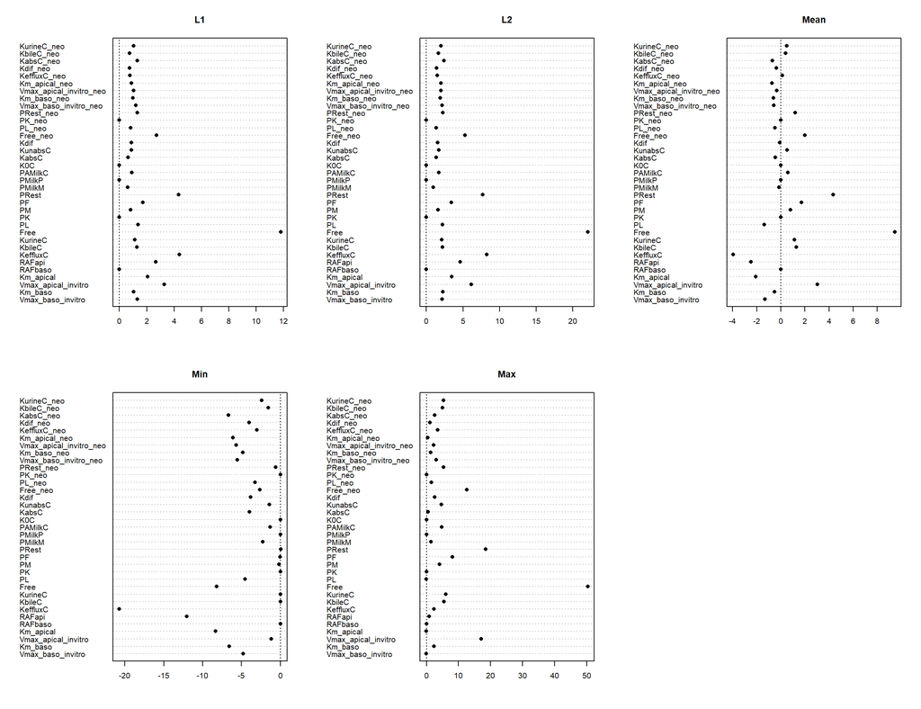

```r
SnsPlasma <- sensFun(func = Lcost, parms = Ltheta.int, varscale = 1)
Sen       <- summary(SnsPlasma)
plot(summary(SnsPlasma))
```

## Select sensitive parameters;

```r
## Selecte the parameters that sensitive scores higher than 2x average socre of all parameters
Ltheta <- Ltheta.int[abs(Sen$Min) > 2*mean(abs(Sen$Min))]
Ltheta
```

```
## Km_apical    RAFapi  KeffluxC      Free
##  4.165114 -6.907755 -1.897120 -4.268698
```

## Select sensitive parameters and relavant parameters based on available calibrated data??? (only select three parameter for optimization due to limited data)

```r
Ltheta <- log(c(
    #Vmax_baso_invitro              = 479,
    #Km_baso                        = 20.1,
    #Vmax_apical_invitro            = 51803,
    #Km_apical                      = 64.4,
    #RAFbaso                        = 1,
    RAFapi                         = 0.001,
    #KeffluxC                       = 0.150,
    #KbileC                         = 1.3e-4,
    #KurineC                        = 0.096,
    Free                           = 0.014,
    #PL                             = 2.03,
    #PK                             = 1.26,
    #PM                             = 0.16,
    #PF                             = 0.13,
    #PRest                          = 0.20,
    #PMilkM                         = 1.9,
    #PMilkP                         = 0.01,
    PAMilkC                        = 0.5
    #K0C                            = 1,
    #KabsC                          = 2.12,
    #KunabsC                        = 7.05e-5,
    #Kdif                           = 0.001,
    #Free_neo                       = 0.014
    #PL_neo                         = 2.03,
    #PK_neo                         = 1.26,
    #PRest_neo                      = 0.20,
    #Vmax_baso_invitro_neo          = 479,
    #Km_baso_neo                    = 20.1,
    #Vmax_apical_invitro_neo        = 51803,
    #Km_apical_neo                  = 64.4,
    #KeffluxC_neo                   = 0.150,
    #Kdif_neo                       = 0.001,
    #KabsC_neo                      = 31.3,
    #KbileC_neo                     = 1.3e-4,
))
```

## Least squares fit using levenberg-marquart algorithm

```r
LFit <- modFit(f = Lcost, p = Ltheta, method ="Marq",
               control = nls.lm.control(nprint = 1))
```

```
## It.    0, RSS =    165.895, Par. =   -6.90776    -4.2687  -0.693147
## It.    1, RSS =    42.0724, Par. =   -5.91591   -3.70687   -2.72982
## It.    2, RSS =    7.56264, Par. =  -0.458536   -3.12805   -7.22817
## It.    3, RSS =     3.0404, Par. =  -0.699556   -3.23099   -5.48344
## It.    4, RSS =     2.3226, Par. =  -0.519216   -3.24282   -5.65958
## It.    5, RSS =    1.64668, Par. =  -0.363319   -3.29555   -5.68443
## It.    6, RSS =    1.60846, Par. =  -0.537977   -3.28909    -5.8688
## It.    7, RSS =    1.60789, Par. =  -0.633888   -3.29453   -5.85696
## It.    8, RSS =    1.60742, Par. =  -0.644214   -3.29276   -5.86381
## It.    9, RSS =    1.60742, Par. =  -0.644215   -3.29276   -5.86381
## It.   10, RSS =    1.60742, Par. =  -0.644215   -3.29276   -5.86381
```

## Summary of fitting results

The model calibration has completed; Now you can check the fitting results and check the parameter values

```r
summary(LFit)   ## Summary of fitting results
```

```
##
## Parameters:
##         Estimate Std. Error t value Pr(>|t|)
## RAFapi  -0.64421    0.08065  -7.988 9.20e-05 ***
## Free    -3.29276    0.03297 -99.858 2.66e-12 ***
## PAMilkC -5.86381    0.36983 -15.855 9.63e-07 ***
## ---
## Signif. codes:  0 '***' 0.001 '**' 0.01 '*' 0.05 '.' 0.1 ' ' 1
##
## Residual standard error: 0.4792 on 7 degrees of freedom
##
## Parameter correlation:
##          RAFapi    Free PAMilkC
## RAFapi   1.0000  0.1802  -0.355
## Free     0.1802  1.0000  -0.384
## PAMilkC -0.3550 -0.3840   1.000
```

```r
exp(LFit$par)   ## Convert the log-transformed parameters to arithmetic values
```

```
##     RAFapi       Free    PAMilkC
## 0.52507460 0.03715117 0.00284040
```

## Check your results

```r
Lcost(LFit$par)
```

```
## $model
## [1] 1.60742
##
## $minlogp
## [1] 9.993095
##
## $var
##        name scale N SSR.unweighted SSR.unscaled          SSR
## 1     CMilk     1 4   0.0022486910 0.0022486910 0.0022486910
## 2 CPlas_pup     1 2   0.0590949215 0.0590949215 0.0590949215
## 3     CPlas     1 1   0.0705211161 0.0705211161 0.0705211161
## 4     CPlas     1 1   0.7859986704 0.7859986704 0.7859986704
## 5     CMilk     1 1   0.0009839377 0.0009839377 0.0009839377
## 6     CPlas     1 1   0.6885726108 0.6885726108 0.6885726108
##
## $residuals
##         name     x   obs         mod weight res.unweighted         res
## 1      CMilk  6888  0.05  0.03631903      1    -0.01368097 -0.01368097
## 2      CMilk  7056  0.05  0.03569355      1    -0.01430645 -0.01430645
## 3      CMilk  7392  0.07  0.03485898      1    -0.03514102 -0.03514102
## 4      CMilk  8904  0.06  0.03506095      1    -0.02493905 -0.02493905
## 5  CPlas_pup 11088  3.30  3.06218314      1    -0.23781686 -0.23781686
## 6  CPlas_pup 13608  2.20  2.14962083      1    -0.05037917 -0.05037917
## 7      CPlas 11088  3.20  3.46555812      1     0.26555812  0.26555812
## 8      CPlas  8904 21.90 21.01343434      1    -0.88656566 -0.88656566
## 9      CMilk  7224  0.20  0.23136778      1     0.03136778  0.03136778
## 10     CPlas  7224 20.70 21.52980275      1     0.82980275  0.82980275
##
## attr(,"class")
## [1] "modCost"
```

# Save results

You can use the function `saveRDS()`save the fitting results to RDS files.

```r
# saveRDS(GFit, file  ='GFit_H.rds')    # Save the fitting results for the gestational PBPK model
# saveRDS(LFit, file  ='LFit_H.rds')   # Save the fitting results for the lactational PBPK model
```